# Activity: Street or Road?

Matt Beckman

November 8, 2017

*Source file* ⇒ StreetRoadActivity.Rmd

# Grading

##### The assignment is worth a total of 10 points.

- [2 points] Turn in HTML with embedded .Rmd file (e.g. “DataComputing simple” template)
- [2 points] Work through the “Solved Example” section showing progress with each step
- Back to the Streets:
  - [2 points] Your Turn #1: explain each line of code in English (either narrative or commented code)
  - [1 point] Your Turn #2: expand to match several more patterns (at least 12 total)
  - [1 point] Your Turn #2: provide a table in **descending order** of popularity for the street name identifiers you found
  - [2 points] Your Turn #2: use `ggplot` to construct a bar chart in **descending order** of popularity for the street name identifiers you found.

##### Assignment Remarks:

Two data sets are provided. One includes 15,000 street addresses of registered voters in Wake County, North Carolina. The other includes over 900,000 street addresses of Medicare Service Providers. You can use either data set (or both!) for the activity.

Note: There’s nothing to do in the “For the professional…” section at the very end except to be impressed.

# Activity

People’s addresses involve streets, lanes, courts, avenues, and so on. How many such road-related words are in common use?

In general, the steps to automate this sort of task might be summarized as follows:

1. In everyday language, describe a patter that you think will identify the information that you’re looking for
2. Translate (1) into a regular expression
3. Filter to retain the cases that match the expression… hint: `filter()` and `grepl()` are useful for this
4. Filter to retain the cases that do not match the expression
5. Examine the results of (3) and (4) to identify shortcomings in your pattern matching algorithm
6. Improve or extend the pattern to deal with the mistaken cases
7. Repeat (1) through (6) until satisfied
8. Put extraction parenthesis around the parts of the regular expression that contain the information you want

### Resources

```r
# 15000 street addresses of registered voters in Wake County, North Carolina
Addresses <- mosaic::read.file("http://tiny.cc/dcf/street-addresses.csv")

# 900,000 street addresses of Medicare Service Providers
download.file(url="http://tiny.cc/dcf/CMS_ProvidersSimple.rds", destfile = "CMS_ProvidersSimple.rds")
AddressesMPS <- readRDS("CMS_ProvidersSimple.rds")
```

### Solved Example

Suppose we want to extract the PO Box number from addresses of the registered voters in Wake County, North Carolina.

```r
# read the address data
Addresses <- read.file("http://tiny.cc/dcf/street-addresses.csv")   # web location
```

```
## Reading data with read.csv()
```

```r
# Addresses <- read.file("street-addresses.csv")                        # local copy

# sample a few dozen cases
Sample <- Addresses %>%
  sample_n(size = 50)
```

1. The PO Box cases tend to have a substring “PO”
2. the regular expression for “PO” is simply `"PO"`
3. Find some cases that match:

```r
Matches <-
  Sample %>%
  filter(grepl("PO", address))
```

4. Find some cases that don’t match:

```r
Dont <-
  Sample %>%
  filter( ! grepl("PO", address))
```

5. Find cases of `Matches` that we don’t want to match, and find cases of `Dont` that we should have matched.

```r
# Inspect Matches
head(Matches)
```

```
##            address
## 1     PO BOX 98055
## 2       PO BOX 165
## 3      PO BOX 1362
## 4      PO BOX 2122
## 5 PO BOX 14081 FSU
## 6       PO BOX 388
```

```r
# Inspect Dont
head(Dont)
```

```
##                  address
## 1 1006 PASTURE BRANCH RD
## 2        1760 BROOKS AVE
## 3         NCSU BOX 15167
## 4     3638 OLYMPIA DRIVE
## 5      2113 N LAMBERT ST
## 6         NCSU BOX 16322
```

6. Maybe “BOX” might be a better pattern, so we’ll try that instead.

```r
# Pattern to locate
pattern <- "BOX\\s+(\\d+)"

# Inspect Matches
Matches <-
  Sample %>%
  filter(grepl(pattern, address))

Matches
```

```
##             address
## 1    NCSU BOX 15167
## 2      PO BOX 98055
## 3        PO BOX 165
## 4       PO BOX 1362
## 5       PO BOX 2122
## 6  PO BOX 14081 FSU
## 7        PO BOX 388
## 8       PO BOX 1303
## 9      PO BOX 12373
## 10      PO BOX 1655
## 11   NCSU BOX 16322
## 12     PO BOX 98722
## 13       PO BOX 382
## 14      PO BOX 2072
```

[output cut: 24 more lines]

```r
# Inspect Dont
Dont <-
  Sample %>%
  filter( ! grepl(pattern, address))

Dont
```

```
##                    address
## 1   1006 PASTURE BRANCH RD
## 2          1760 BROOKS AVE
## 3       3638 OLYMPIA DRIVE
## 4        2113 N LAMBERT ST
## 5            3135 TRYON RD
## 6   111 LAUREL CREEK DRIVE
## 7          1810 BENNETT ST
## 8       1810 N NEW HOPE RD
## 9   302 SOUTHTOWN CIRCLE 1
## 10 3311 WHARTON STATION RD
## 11         5120 CASLAND DR
## 12   8711-104 SIX FORKS RD
```

We’ll now use `tidyr::extract()` to pull the part of the pattern identified by the extraction parenthesis.

```r
BoxNumbers <-
  Sample %>%
  filter(grepl(pattern, address)) %>%
  tidyr::extract(address, into = "boxnum", regex = pattern)

head(BoxNumbers, 10)
```

```
##    boxnum
## 1   15167
## 2   98055
## 3     165
## 4    1362
## 5    2122
## 6   14081
## 7     388
## 8    1303
## 9   12373
## 10   1655
```

### Back to the Streets

We’ll go line-by-line explaining the following code chunk:

```
pattern <- "(ST|RD|ROAD)"

LeftOvers <-
  Addresses %>%
  filter( ! grepl(pattern, address),
          ! grepl("\\sAPT|UNIT\\s[\\d]+$", address),
          ! grepl("BOX|BX", address))
```

This is the regular expression we want to extract (e.g. ST, RD, ROAD):

```
pattern <- "(ST|RD|ROAD)"
```

Assign all remaining non-matches to data set called called `LeftOvers`:

```
LeftOvers <-
```

Start with the `Addresses` data set:

```
  Addresses %>%
```

Remove the cases that we want to match:

```
  filter( ! grepl(pattern, address),
```

Remove some known cases (apartments, etc) that we know we don’t want:

```
          ! grepl("\\sAPT|UNIT\\s[\\d]+$", address),
```

Remove some more known cases (PO Boxes) that we know we don’t want:

```
          ! grepl("BOX|BX", address))
```

Here’s the whole thing together:

```r
pattern <- "(ST|RD|ROAD)"

LeftOvers <-
  Addresses %>%
  filter( ! grepl(pattern, address),
          ! grepl("\\sAPT|UNIT\\s[\\d]+$", address),
          ! grepl("BOX|BX", address))

# Inspect the result
head(LeftOvers, 10)
```

```
##                address
## 1  2117 MARINER CIRCLE
## 2       101 EPPING WAY
## 3    04-I ROBIN CIRCLE
## 4       NCSU B0X 15637
## 5     4719 BROWN TRAIL
## 6       130 THE WINERY
## 7       5250 ADAMS AVE
## 8   7416 IVY LEAGUE LN
## 9    12629 WATERMAN DR
## 10            HMIA-267
```

### Your Turn: Explain your method & present result (use `ggplot()`)

Iterate the method to select more of the desired street & road identifiers.

```r
# regular expression we want to extract including several different street & road abbreviations
pattern <- "(AVENUE|AVE|BLVD|BLV|CIRCLE|CIR|COURT|CT|DRIVE|DR|LN|LANE|LOOP|PATH|PL|PLACE|PKWY|RD|ROAD|RUN|ST|STREET|TERRACE|TRAIL|WAY)"

LeftOvers <-               # reduced data set of non-matches will be called `LeftOvers`
  Addresses %>%            # start with all the addresses
  filter( ! grepl(pattern, address),                    # remove the current pattern we like
          ! grepl("\\sAPT|UNIT\\s[\\d]+$", address),    # remove APT & UNIT addresses we don't want
          ! grepl("BOX|BX", address),                   # remove PO BOX addresses we don't want
          ! grepl("HALL", address))                     # remove HALL addresses we don't want

head(LeftOvers, 30)            # inspect the LeftOvers data
```

```
##                            address
## 1                   NCSU B0X 15637
## 2                   130 THE WINERY
## 3                         HMIA-267
## 4                     311 BAREFOOT
## 5                    512  LIVE OAK
## 6          1706 WINGATE UNIVERSITY
## 7                   AT BN BRAVO CO
## 8                          UR 6516
## 9             104 SILVERWOOD POINT
## 10  PMB 387  6325-9 FALLS OF NEUSE
## 11         2440 SW CARY PARKWA 160
## 12                20 CHAPEL SQUARE
## 13                  103 SUNRISE CV
## 14 9099 MAIL SERVICE CENTER ACP 39
```

[output cut: 16 more lines]

Now that we’ve reached a point where there isn’t too much of value left in the sample of `LeftOvers` from the `Address` data, we’ll stop here. Next, we filter to just include the matches that we want, and then show the results as a sorted table and a plot.

```r
# regular expression we want to extract including several different street & road abbreviations
pattern <- "(AVENUE|AVE|BLVD|BLV|CIRCLE|CIR|COURT|CT|DRIVE|DR|LN|LANE|LOOP|PATH|PL|PLACE|PKWY|RD|ROAD|RUN|ST|STREET|TERRACE|TRAIL|WAY)"

# Set of matches extracted
RoadNames <-
  Addresses %>%
  filter(grepl(pattern, address)) %>%
  tidyr::extract(address, into = "name", regex = pattern)

# frequency table
RoadNameFrequency <-
  RoadNames %>%
  group_by(name) %>%
  summarise(count = n()) %>%
  mutate(name = reorder(name, desc(count))) %>%
  arrange(desc(count))
```

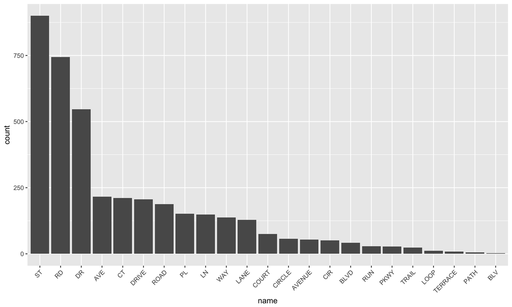

```r
# Bar chart of frequency
RoadNameFrequency %>%
  ggplot(aes(x = name, y = count)) +
  geom_bar(stat = "identity") +
  theme(axis.text.x = element_text(angle = 45, hjust = 1))
```

```r
# Frequency table street identifiers
knitr::kable(RoadNameFrequency, align = c('c', 'l'), padding = 0)
```

| name | count |
| --- | --- |
| ST | 900 |
| RD | 744 |
| DR | 547 |
| AVE | 216 |
| CT | 211 |
| DRIVE | 206 |
| ROAD | 188 |
| PL | 152 |
| LN | 149 |
| WAY | 137 |
| LANE | 128 |
| COURT | 75 |
| CIRCLE | 57 |
| AVENUE | 54 |
| CIR | 51 |
| BLVD | 42 |
| RUN | 29 |
| PKWY | 28 |
| TRAIL | 24 |
| LOOP | 12 |
| TERRACE | 8 |
| PATH | 5 |
| BLV | 2 |